# STAT340 HW10: Prediction III, logistic regression

Ben Hayum

November 2022

No other students.

## Instructions

Update the “author” and “date” fields in the header and complete the exercises below. Knit the document, and submit **both the HTML and RMD** files to Canvas.

**Due date:** December 1, 2022 at 11:59pm.

This homework will review our discussion of logistic regression from this week’s lectures.

## 1) Interpreting logistic regression

Suppose we collect data for a group of students in a statistics class with independent variables $X_{1}=\text{hours studied}$, $X_{2}=\text{GPA}$, and binary response variable
$$Y= \begin{cases} 1 &\mbox{ if student received an A} \\
0 &\mbox{ otherwise. }
\end{cases}$$
Suppose that we fit a logistic regression model to the data, predicting $Y$ from $X_1$ and $X_2$ (and an intercept term) and produce estimated coefficients $\hat{\beta}_{0}=-6, \hat{\beta}_{1}=0.05, \hat{\beta}_{2}=1$.

### Part a) Logistic regression and probability

According to our fitted model, what is the probability that a student receives an A if they study for $40$ hours and have a GPA of $3.5$?

```r
log_odds = -6 + .05*40 + 1*3.5
odds = exp(log_odds)
odds
```

```
## [1] 0.6065307
```

### Part b) Interpreting coefficients

According to our fitted model, an additional hour spent studying is associated with *how much* of an increase in the log odds of receiving an A?

An additional hour spent studying is associated with an increase in .05 of the log odds of receiving an A

### Part c) “Inverting” logistic regression probabilities

According to our fitted model, how many hours would the student in Part (a) need to study to have a $50\%$ chance of getting an A in the class? That is, keeping GPA fixed at $3.5$, how many hours of study are needed so that the probability of an A is $50\%$? If you aren’t up for the math, feel free to find an approximate solution via guess-and-check in R.

```r
# .5 = e^(-6 + .05*hours + 1*3.5)
# ln(.5) = -6 + .05*hours + 1*3.5
# ln(.5) + 2.5 = .05*hours
# (ln(.5) + 2.5)/.05 = hours
hours = (log(.5) + 2.5)/.05
hours
```

```
## [1] 36.13706
```

```r
# Checking that it works
odds = exp(-6 + hours*.05 + 3.5)
odds
```

```
## [1] 0.5
```

## 2) `mtcars` once again

Let’s take yet another look at the `mtcars` data set. Recall that the columns of this data set are:

```r
names(mtcars)
```

```
##  [1] "mpg"  "cyl"  "disp" "hp"   "drat" "wt"   "qsec" "vs"   "am"   "gear"
## [11] "carb"
```

The `am` column encodes whether a car is automatic (`0`) or manual (`1`). Let’s build a model to predict whether a car is manual or automatic.

### Part a) Fitting a model

Fit a logistic regression model to regress `am` against the `drat` and `disp` (and an intercept term).

```r
model = glm(am ~ 1 + drat + disp, data = mtcars, family = "binomial")
summary(model)
```

```
##
## Call:
## glm(formula = am ~ 1 + drat + disp, family = "binomial", data = mtcars)
##
## Deviance Residuals:
##     Min       1Q   Median       3Q      Max
## -1.5773  -0.2273  -0.1155   0.5196   1.8957
##
## Coefficients:
##               Estimate Std. Error z value Pr(>|z|)
## (Intercept) -17.638452   9.165482  -1.924   0.0543 .
## drat          4.879396   2.268115   2.151   0.0315 *
## disp         -0.004153   0.006621  -0.627   0.5305
## ---
## Signif. codes:  0 '***' 0.001 '**' 0.01 '*' 0.05 '.' 0.1 ' ' 1
##
## (Dispersion parameter for binomial family taken to be 1)
##
##     Null deviance: 43.230  on 31  degrees of freedom
## Residual deviance: 21.268  on 29  degrees of freedom
## AIC: 27.268
##
## Number of Fisher Scoring iterations: 6
```

### Part b) Interpreting estimates

Which coefficients (if any) are statistically significantly different from zero at the $\alpha=0.05$ level? Interpret the meaning of the estimated coefficient(s) that is/are statistically significantly different from zero.

The only coefficient that is statistically significant at the alpha = .05 level is drat, the rear axle ratio, which has a value of 4.879396

### Part c) paring down the model

Choose one of the statistically significant predictors above and re-fit a model using *only* that variable (and an intercept) to predict `am`. We’ll see how to compare the quality of this model to the one from Part (a) when we talk about cross-validation (CV) in upcoming lectures. For now, compare the estimated coefficient of this variable in both models. Is there a sizable difference?

Does anything else notable change about the model?

```r
model2 = glm(am ~ 1 + drat, data = mtcars, family = "binomial")
summary(model2)
```

```
##
## Call:
## glm(formula = am ~ 1 + drat, family = "binomial", data = mtcars)
##
## Deviance Residuals:
##     Min       1Q   Median       3Q      Max
## -1.5495  -0.2609  -0.1505   0.5382   1.7453
##
## Coefficients:
##             Estimate Std. Error z value Pr(>|z|)
## (Intercept)  -21.021      7.838  -2.682  0.00732 **
## drat           5.577      2.063   2.704  0.00685 **
## ---
## Signif. codes:  0 '***' 0.001 '**' 0.01 '*' 0.05 '.' 0.1 ' ' 1
##
## (Dispersion parameter for binomial family taken to be 1)
##
##     Null deviance: 43.23  on 31  degrees of freedom
## Residual deviance: 21.65  on 30  degrees of freedom
## AIC: 25.65
##
## Number of Fisher Scoring iterations: 6
```

Beta_0/the intercept also becomes statistically significant when using drat as the only predictor, and Beta_1 becomes even more significant than it previously was

### Part d) Plotting your findings

Choose one of the statistically significant predictors above. Use `ggplot2` to plot `am` as a function of this predictor, and overlay a curve describing the logistic regression output when using *only* this predictor to predict `am` (i.e., the model from Part c above).

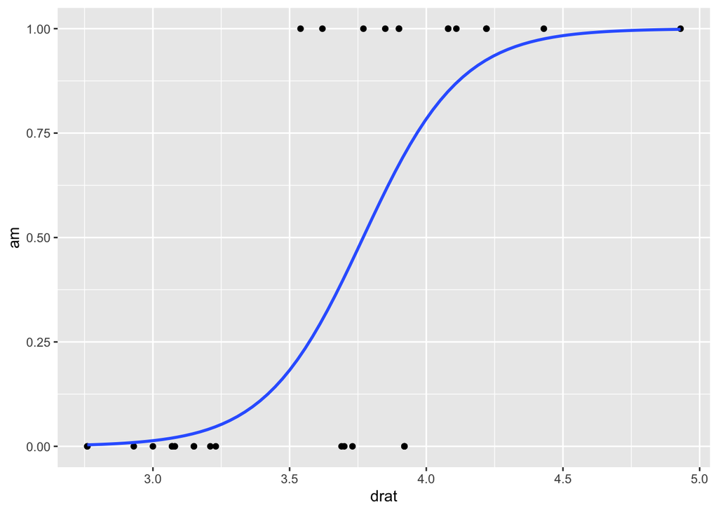

```r
# Using the intercept predictor as well here it seems like...

library(ggplot2)
ggplot(data = mtcars, aes(x = drat, y = am)) +
  geom_point() +
  geom_smooth(formula='y ~ 1+x', method='glm', method.args=list(family = "binomial"), se = FALSE)
```